# NDFS Contaminants Manuscript

Analyses of Total Concentrations in Water and Zooplankton

Dave Bosworth

July 06, 2023

# Purpose

Run statistical analyses for Figure 4 in the NDFS contaminants manuscript to support the figure. Figure 4 shows the total pesticide concentrations in water and zooplankton samples collected from the Sacramento River (SHR) and Toe Drain (STTD) in the summer-fall periods in 2017, 2018 and 2019.

# Global code and functions

```r
# Load packages
library(tidyverse)
library(rlang)
library(patchwork)
library(car)
library(emmeans)
library(visreg)
library(here)
library(conflicted)

# Declare package conflict preferences
conflicts_prefer(dplyr::filter())
```

```r
# Check if we are in the correct working directory
i_am("manuscript_contam/src/contam_conc_water_zoop_analysis.Rmd")
```

```
## here() starts at C:/Repositories/04_IEP_Org/ND-FASTR
```

Create function to plot model diagnostics:

```r
# Create model diagnostic plots to check assumptions
plot_model_diag <- function(df_data, param_var, unit_label, model, log_trans = FALSE, ...) {
  df_data <- df_data %>%
    mutate(
      Residuals = resid(model),
      Fitted = predict(model)
    )

  param_name <- as_name(ensym(param_var))

  if (log_trans == TRUE) {
    unit_label <- paste0("log[", unit_label, "]")
  }

  plt_hist <- ggplot(df_data, aes(x = Residuals)) +
    geom_histogram(...) +
    labs(
      title = "Residual Histogram",
      x = "Residuals"
    ) +
    theme_bw()

  plt_qq <- ggplot(df_data, aes(sample = Residuals)) +
    labs(
      title = "Residual Probability Plot",
      x = "Normal Quantiles",
      y = "Residuals"
    ) +
    stat_qq() +
    stat_qq_line(linewidth = 1, color = 'red') +
    theme_bw()

  plt_res_fit <- ggplot(df_data, aes(x = Fitted, y = Residuals)) +
    geom_point() +
    labs(
      title = "Residuals vs. Fitted Values",
      x = (paste0("Predicted ", param_name, " (", unit_label, ")")),
      y = paste0("Residuals (", unit_label, ")")
    ) +
    theme_bw()

  plt_obs_fit <- ggplot(df_data, aes(x = Fitted, y = {{ param_var}})) +
    geom_point() +
    geom_abline(slope = 1, intercept = 0, color = "red") +
    labs(
      title = "Observed vs. Fitted Values",
      x = paste0("Predicted ", param_name, " (", unit_label, ")"),
      y = paste0("Observed ", param_name, " (", unit_label, ")")
    ) +
    theme_bw()

  (plt_hist + plt_qq) / (plt_res_fit + plt_obs_fit)
}
```

# Import and Prepare Data

```r
# Total Pesticide Concentration data:
df_conc_all <- read_rds(here("manuscript_contam/data/processed/contam_conc_water_zoop_2017-2019.rds"))

# Daily average flow data:
df_davg_flow <- read_rds(here("Water_Quality/Data_Processed/LIS_SR_DailyAvgFlow_2013-2022.rds"))
```

Join the concentration and flow data - SHR with SR at Freeport, and STTD with LIS. Use Daily Average Net flows for both.

```r
df_conc_flow_shr <- df_conc_all %>%
  filter(Station == "SHR") %>%
  left_join(
    df_davg_flow %>% select(Date, DailyAvgNetFlow = SR_DailyAvgNetFlow),
    by = join_by(Date)
  )

df_conc_flow_sttd <- df_conc_all %>%
  filter(Station == "STTD") %>%
  left_join(
    df_davg_flow %>% select(Date, DailyAvgNetFlow = LIS_DailyAvgNetFlow),
    by = join_by(Date)
  )

# Combine data
df_conc_flow_all <- bind_rows(df_conc_flow_shr, df_conc_flow_sttd)

# Look at all data
print(df_conc_flow_all, n = 70)
```

```
## # A tibble: 63 × 5
##    Date       Station TotalConc_Zoop TotalConc_Water DailyAvgNetFlow
##    <date>     <chr>            <dbl>           <dbl>           <dbl>
##  1 2017-08-29 SHR              227.            389.         21200
##  2 2017-09-12 SHR              174.            397.         22100
##  3 2017-09-19 SHR              138.            147.         21500
##  4 2017-10-03 SHR              317.             80.3        19400
##  5 2017-10-17 SHR              427.             47.9        11700
##  6 2017-11-01 SHR              266.             97.3        10400
##  7 2018-07-12 SHR              219.            189.         15700
##  8 2018-07-25 SHR              165.            262.         16500
##  9 2018-08-09 SHR              413.            669.         20200
## 10 2018-08-23 SHR              303.            564.         17500
## 11 2018-09-06 SHR              324.            318.         18000
## 12 2018-09-20 SHR              270.            151.         16500
```

[output cut: 51 more lines]

It looks like all of the flow data was available for SHR, but STTD is missing a few flow values in July 2019. We’ll restrict the date ranges to July 1 - Oct 31 for each year since some of the data extends outside of the summer-fall period.

```r
df_conc_flow_all_c <- df_conc_flow_all %>% filter(month(Date) %in% 7:10)

# Look at filtered data
print(df_conc_flow_all_c, n = 50)
```

```
## # A tibble: 45 × 5
##    Date       Station TotalConc_Zoop TotalConc_Water DailyAvgNetFlow
##    <date>     <chr>            <dbl>           <dbl>           <dbl>
##  1 2017-08-29 SHR              227.            389.         21200
##  2 2017-09-12 SHR              174.            397.         22100
##  3 2017-09-19 SHR              138.            147.         21500
##  4 2017-10-03 SHR              317.             80.3        19400
##  5 2017-10-17 SHR              427.             47.9        11700
##  6 2018-07-12 SHR              219.            189.         15700
##  7 2018-07-25 SHR              165.            262.         16500
##  8 2018-08-09 SHR              413.            669.         20200
##  9 2018-08-23 SHR              303.            564.         17500
## 10 2018-09-06 SHR              324.            318.         18000
## 11 2018-09-20 SHR              270.            151.         16500
## 12 2018-10-11 SHR              651.             98.9        11600
```

[output cut: 33 more lines]

# Zooplankton Analysis

```r
# Prepare zooplankton concentration data for analysis
df_zoop <- df_conc_flow_all_c %>%
  select(-TotalConc_Water) %>%
  drop_na() %>%
  # Remove two samples with total concentrations equal to zero
  filter(TotalConc_Zoop > 0) %>%
  mutate(Year = as.character(year(Date)), .after = Date)
```

## Exploratory Plots

Before running the analyses, lets take a look at how the total pesticide concentrations in zooplankton vary with daily average net flow for each station.

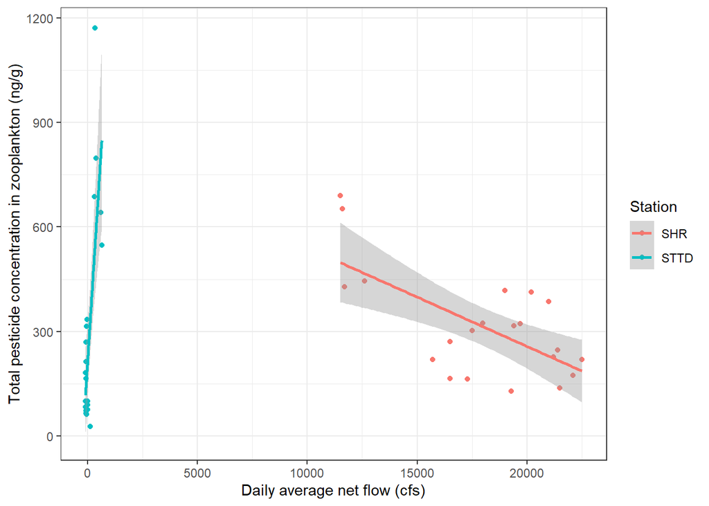

```r
df_zoop %>%
  ggplot(aes(x = DailyAvgNetFlow, y = TotalConc_Zoop, color = Station)) +
  geom_point() +
  geom_smooth(method = "lm", formula = y ~ x) +
  labs(
    x = "Daily average net flow (cfs)",
    y = "Total pesticide concentration in zooplankton (ng/g)"
  ) +
  theme_bw()
```

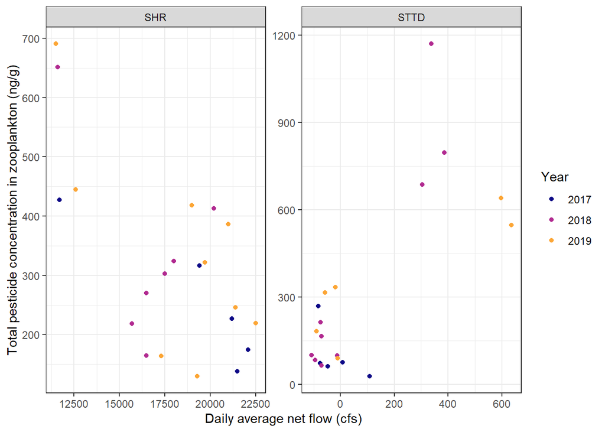

```r
df_zoop %>%
  ggplot(aes(x = DailyAvgNetFlow, y = TotalConc_Zoop, color = Year)) +
  geom_point() +
  scale_color_viridis_d(option = "plasma", end = 0.8) +
  facet_wrap(vars(Station), scales = "free") +
  labs(
    x = "Daily average net flow (cfs)",
    y = "Total pesticide concentration in zooplankton (ng/g)"
  ) +
  theme_bw()
```

SHR seems to have no or a weak negative relationship between concentration and flow, while concentrations at STTD seem to have a positive relationship with flow. The ranges of the daily average flows don’t overlap between the two stations, so it may not make sense to run the Station-Flow model including both stations.

Next, lets look at a boxplot comparing total pesticide concentrations in zooplankton between stations.

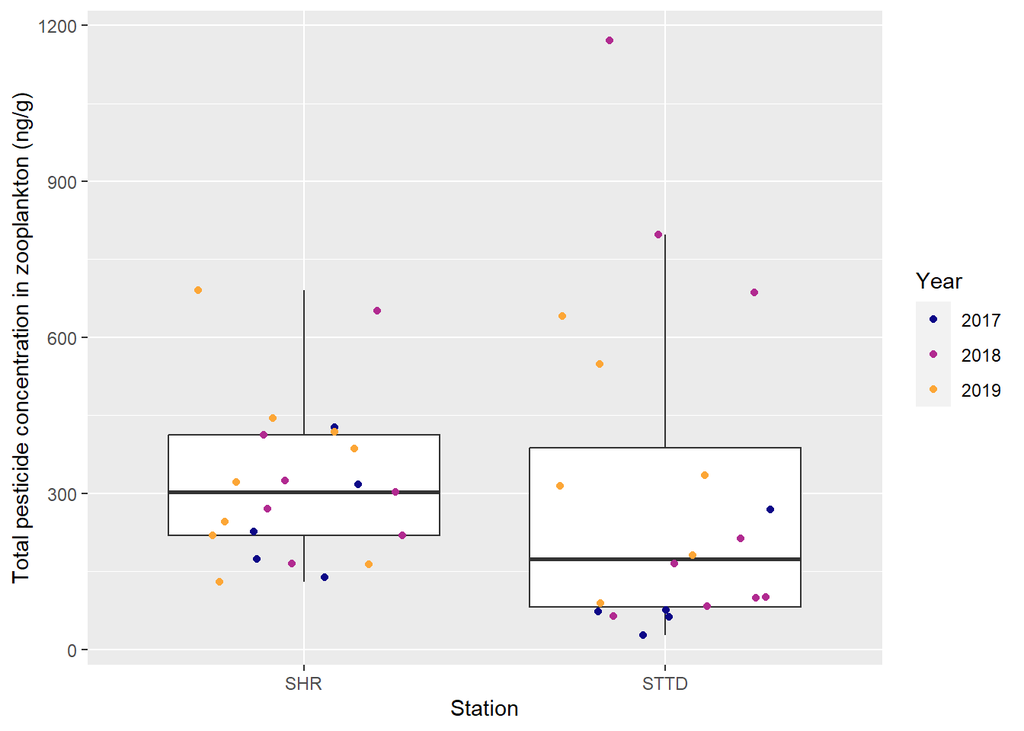

```r
df_zoop %>%
  ggplot(aes(x = Station, y = TotalConc_Zoop)) +
  geom_boxplot(outlier.shape = NA) +
  geom_jitter(aes(color = Year), width = 0.3) +
  scale_color_viridis_d(option = "plasma", end = 0.8) +
  ylab("Total pesticide concentration in zooplankton (ng/g)")
```

SHR has a higher median concentration than STTD, but STTD has some higher values than SHR particularly in 2018. Let’s break apart the boxplot by station and year.

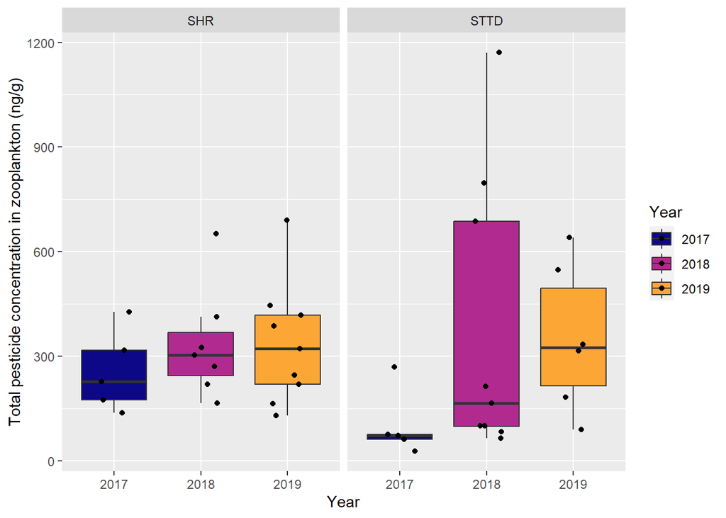

```r
df_zoop %>%
  ggplot(aes(x = Year, y = TotalConc_Zoop, fill = Year)) +
  geom_boxplot(outlier.shape = NA) +
  geom_jitter(width = 0.2) +
  facet_wrap(vars(Station)) +
  scale_fill_viridis_d(option = "plasma", end = 0.8) +
  ylab("Total pesticide concentration in zooplankton (ng/g)")
```

Overall, STTD in 2018 had the highest concentrations. Let’s look at a boxplot grouped only by year.

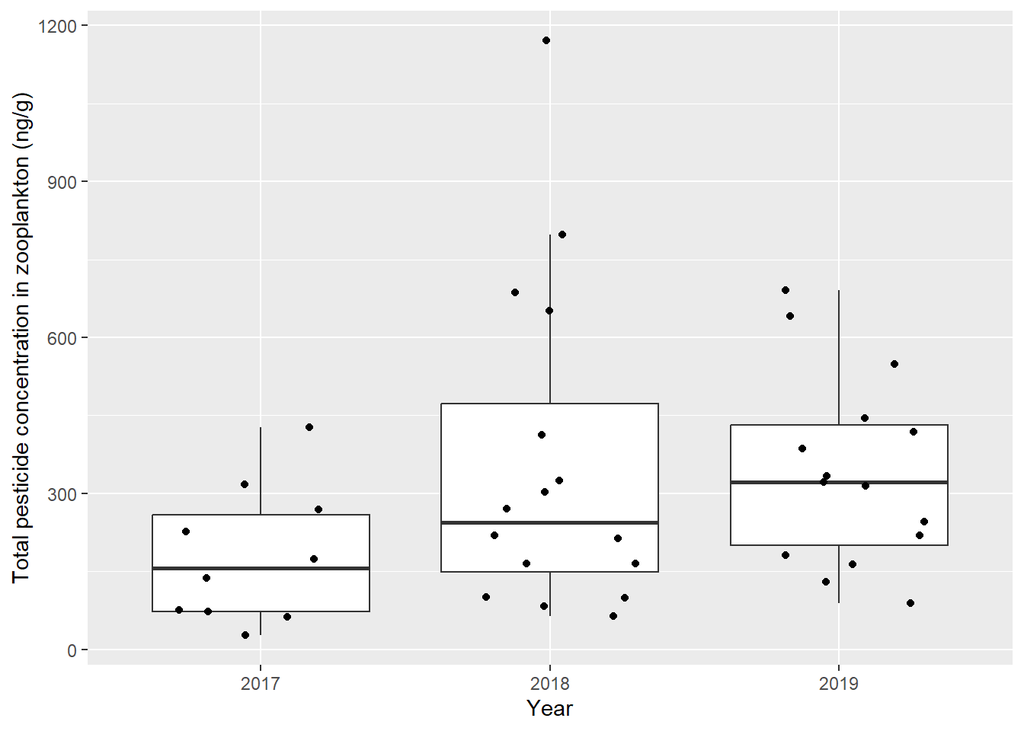

```r
df_zoop %>%
  ggplot(aes(x = Year, y = TotalConc_Zoop)) +
  geom_boxplot(outlier.shape = NA) +
  geom_jitter(width = 0.3) +
  ylab("Total pesticide concentration in zooplankton (ng/g)")
```

The median of total concentrations was slightly higher in 2019 than other years when both stations are grouped together.

Now, let’s see how total concentrations varied seasonally using day of year for each station and year.

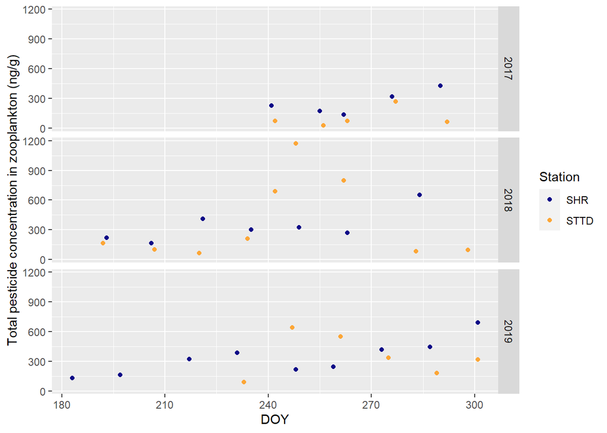

```r
df_zoop %>%
  ggplot(aes(x = yday(Date), y = TotalConc_Zoop, color = Station)) +
  geom_point() +
  facet_grid(rows = vars(Year)) +
  scale_color_viridis_d(option = "plasma", end = 0.8) +
  labs(x = "DOY", y = "Total pesticide concentration in zooplankton (ng/g)")
```

Lastly, let’s take a look at the histogram of all total pesticide concentrations in zooplankton to look at its distribution.

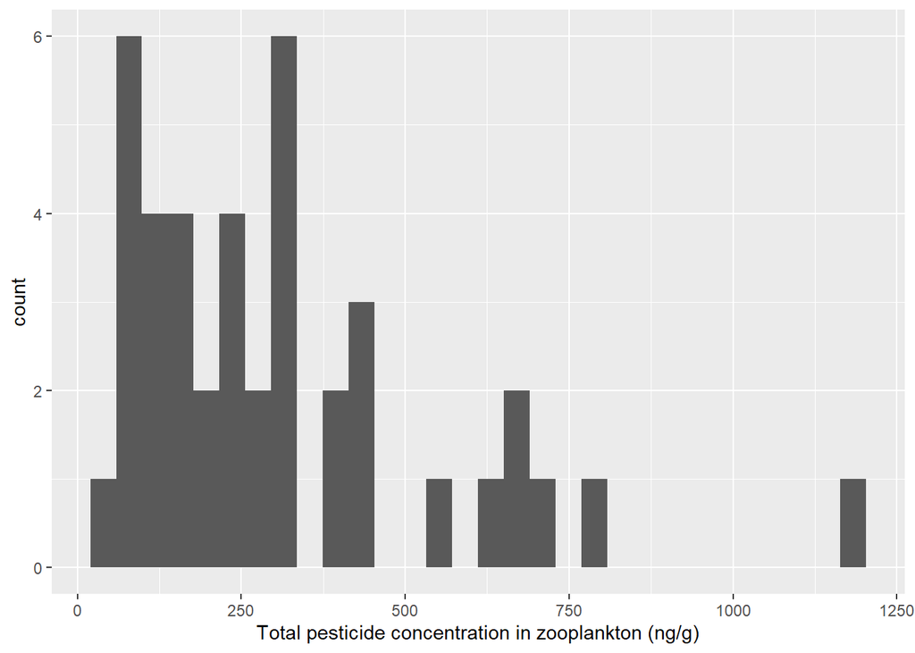

```r
df_zoop %>%
  ggplot(aes(x = TotalConc_Zoop)) +
  geom_histogram() +
  xlab("Total pesticide concentration in zooplankton (ng/g)")
```

We may need to transform the zooplankton concentration data for the analyses.

## Analyses

### Model with Station and Flow

We’ll create a linear model of the zooplankton concentrations as a function of the interaction between station and daily average net flow. We’ll start with the original concentration values, but we may need to transform them. This model will allow us to examine:

1. Do total pesticide concentrations in zooplankton significantly respond to flow at either or both SHR and STTD?
2. Whether total pesticide concentrations in zooplankton are significantly higher at one of the stations controlling for the effect of flow. This can only be assessed if the interaction between station and daily average net flow isn’t significant.

```r
m_zoop_sta_flow <- df_zoop %>% lm(TotalConc_Zoop ~ Station * DailyAvgNetFlow, data = .)
```

Plot the diagnostics

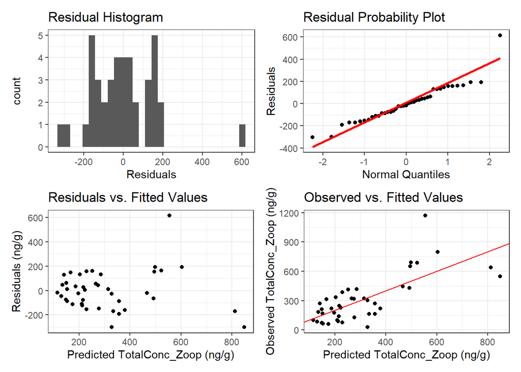

```r
df_zoop %>% plot_model_diag(TotalConc_Zoop, "ng/g", m_zoop_sta_flow)
```

```r
shapiro.test(m_zoop_sta_flow$residuals)
```

```
##
##  Shapiro-Wilk normality test
##
## data:  m_zoop_sta_flow$residuals
## W = 0.91871, p-value = 0.006208
```

The residuals deviate from a normal distribution according to the Shapiro-Wilk normality test and visual inspection. We’ll re-run the model using the natural log of the concentration values.

```r
df_zoop_log <- df_zoop %>% mutate(TotalConc_Zoop = log(TotalConc_Zoop))

m_zoop_sta_flow_log <- df_zoop_log %>% lm(TotalConc_Zoop ~ Station * DailyAvgNetFlow, data = .)
```

Plot the diagnostics

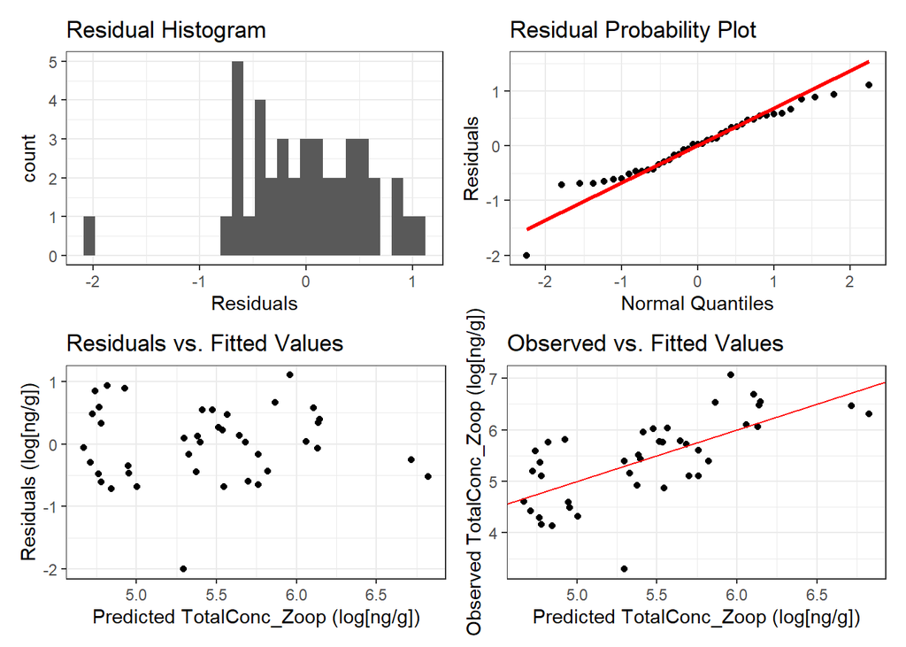

```r
df_zoop_log %>% plot_model_diag(TotalConc_Zoop, "ng/g", m_zoop_sta_flow_log, log_trans = TRUE)
```

```r
shapiro.test(m_zoop_sta_flow_log$residuals)
```

```
##
##  Shapiro-Wilk normality test
##
## data:  m_zoop_sta_flow_log$residuals
## W = 0.95155, p-value = 0.07931
```

This is somewhat better than the model with original values. Let’s take a look at the Anova table using type 3 sum of squares for the model using log transformation.

```r
Anova(m_zoop_sta_flow_log, type = 3, contrasts = list(topic = contr.sum, sys = contr.sum))
```

```
## Anova Table (Type III tests)
##
## Response: TotalConc_Zoop
##                         Sum Sq Df F value    Pr(>F)
## (Intercept)             37.854  1 97.5084 6.464e-12 ***
## Station                  3.087  1  7.9513  0.007677 **
## DailyAvgNetFlow          1.515  1  3.9032  0.055689 .
## Station:DailyAvgNetFlow  9.442  1 24.3229 1.741e-05 ***
## Residuals               14.364 37
## ---
## Signif. codes:  0 '***' 0.001 '**' 0.01 '*' 0.05 '.' 0.1 ' ' 1
```

The significant interaction between station and daily average net flow indicates that the regression slopes are different between the two stations. This isn’t surprising looking at the concentration vs flow plots above. The Anova table also shows that the main effect of station was significant while the main effect of flow wasn’t. These probably shouldn’t be interpreted as such since the interaction term is strongly significant. To look at how flow affects total pesticide concentrations in zooplankton, we’ll need to run separate models for each station.

#### SHR

We’ll start with SHR

```r
df_zoop_shr <- df_zoop %>% filter(Station == "SHR")

m_zoop_flow_shr <- df_zoop_shr %>% lm(TotalConc_Zoop ~ DailyAvgNetFlow, data = .)
```

Plot the diagnostics

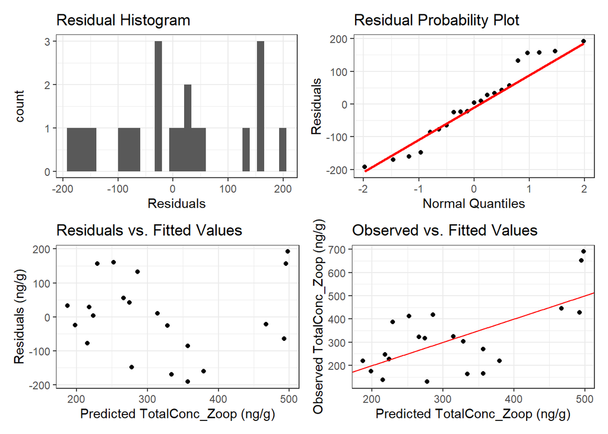

```r
df_zoop_shr %>% plot_model_diag(TotalConc_Zoop, "ng/g", m_zoop_flow_shr)
```

```r
shapiro.test(m_zoop_flow_shr$residuals)
```

```
##
##  Shapiro-Wilk normality test
##
## data:  m_zoop_flow_shr$residuals
## W = 0.95249, p-value = 0.3792
```

The model diagnostics actually look pretty good with the original values, so we’ll take a closer look at this model.

```r
summary(m_zoop_flow_shr)
```

```
##
## Call:
## lm(formula = TotalConc_Zoop ~ DailyAvgNetFlow, data = .)
##
## Residuals:
##      Min       1Q   Median       3Q      Max
## -191.654  -77.207    3.509   55.979  192.416
##
## Coefficients:
##                   Estimate Std. Error t value Pr(>|t|)
## (Intercept)     823.411968 136.026840   6.053 8.02e-06 ***
## DailyAvgNetFlow  -0.028289   0.007454  -3.795  0.00122 **
## ---
## Signif. codes:  0 '***' 0.001 '**' 0.01 '*' 0.05 '.' 0.1 ' ' 1
##
## Residual standard error: 119 on 19 degrees of freedom
## Multiple R-squared:  0.4312, Adjusted R-squared:  0.4013
## F-statistic:  14.4 on 1 and 19 DF,  p-value: 0.001223
```

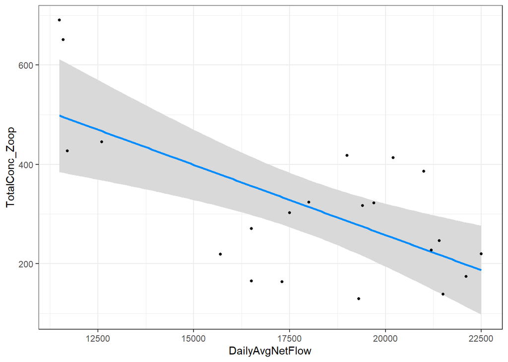

```r
visreg(m_zoop_flow_shr, gg = TRUE) + theme_bw() + geom_point(size = 1)
```

Total pesticide concentrations decrease significantly with flow at the SHR station; however, there is a gap in samples between 13,000-16,000 cfs.

#### STTD

Next, we’ll look at STTD

```r
df_zoop_sttd <- df_zoop %>% filter(Station == "STTD")

m_zoop_flow_sttd <- df_zoop_sttd %>% lm(TotalConc_Zoop ~ DailyAvgNetFlow, data = .)
```

Plot the diagnostics

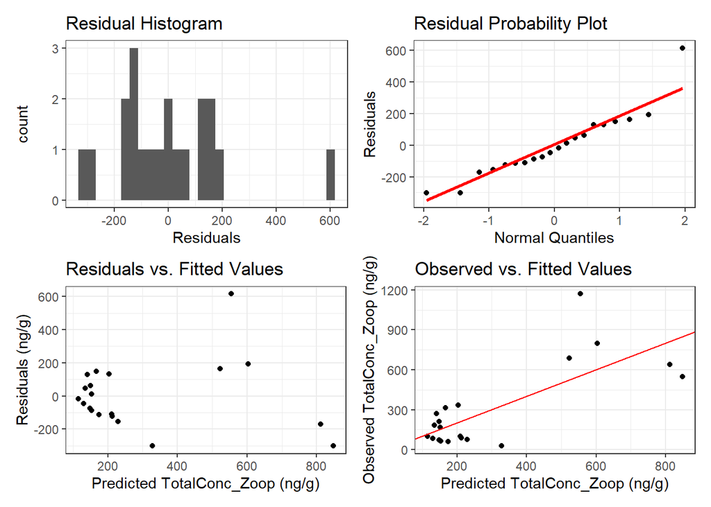

```r
df_zoop_sttd %>% plot_model_diag(TotalConc_Zoop, "ng/g", m_zoop_flow_sttd)
```

```r
shapiro.test(m_zoop_flow_sttd$residuals)
```

```
##
##  Shapiro-Wilk normality test
##
## data:  m_zoop_flow_sttd$residuals
## W = 0.90435, p-value = 0.04979
```

The residuals deviate from a normal distribution according to the Shapiro-Wilk normality test and visual inspection. We’ll re-run the model using the natural log transformation since that worked well for all data combined.

```r
df_zoop_sttd_log <- df_zoop_sttd %>% mutate(TotalConc_Zoop = log(TotalConc_Zoop))

m_zoop_flow_sttd_log <- df_zoop_sttd_log %>% lm(TotalConc_Zoop ~ DailyAvgNetFlow, data = .)
```

Plot the diagnostics

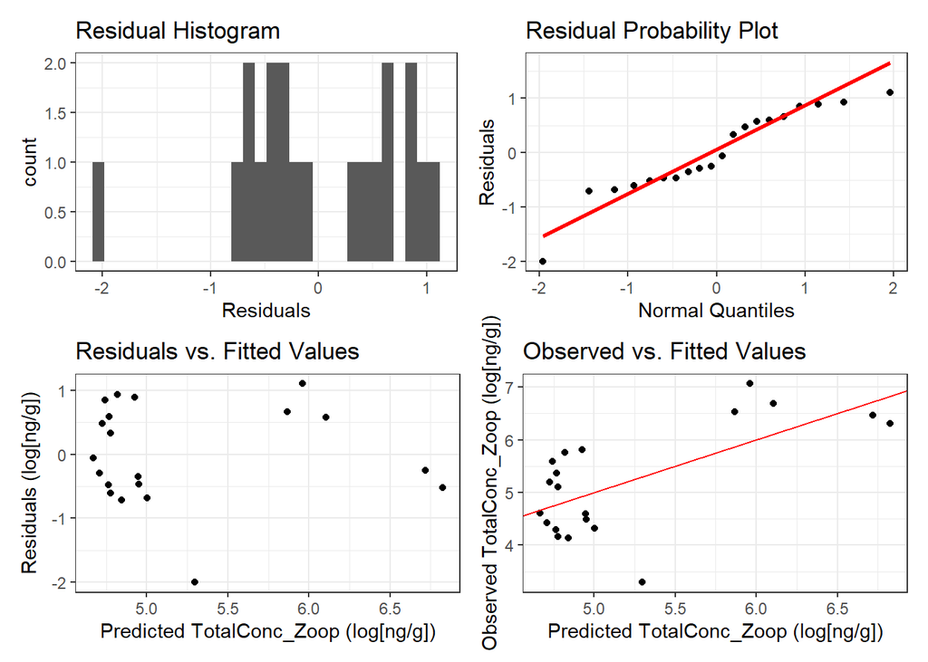

```r
df_zoop_sttd_log %>% plot_model_diag(TotalConc_Zoop, "ng/g", m_zoop_flow_sttd_log, log_trans = TRUE)
```

```r
shapiro.test(m_zoop_flow_sttd_log$residuals)
```

```
##
##  Shapiro-Wilk normality test
##
## data:  m_zoop_flow_sttd_log$residuals
## W = 0.92147, p-value = 0.1058
```

The natural log transformation worked pretty well for this data. Let’s take a closer look at this model.

```r
summary(m_zoop_flow_sttd_log)
```

```
##
## Call:
## lm(formula = TotalConc_Zoop ~ DailyAvgNetFlow, data = .)
##
## Residuals:
##     Min      1Q  Median      3Q     Max
## -2.0022 -0.4843 -0.1585  0.6111  1.1052
##
## Coefficients:
##                  Estimate Std. Error t value Pr(>|t|)
## (Intercept)     4.9818978  0.1880497  26.492 7.17e-16 ***
## DailyAvgNetFlow 0.0029026  0.0007706   3.767  0.00141 **
## ---
## Signif. codes:  0 '***' 0.001 '**' 0.01 '*' 0.05 '.' 0.1 ' ' 1
##
## Residual standard error: 0.7963 on 18 degrees of freedom
## Multiple R-squared:  0.4408, Adjusted R-squared:  0.4097
## F-statistic: 14.19 on 1 and 18 DF,  p-value: 0.001412
```

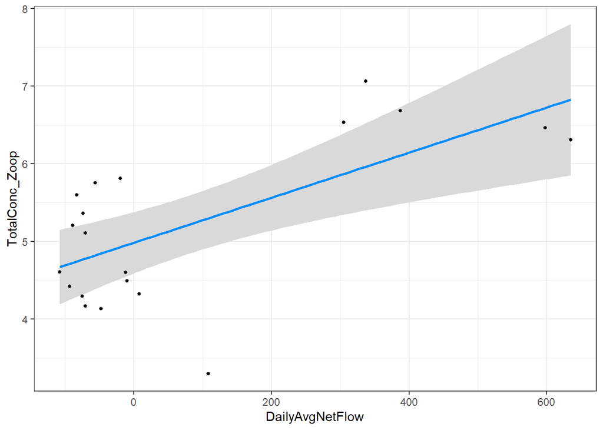

```r
visreg(m_zoop_flow_sttd_log, gg = TRUE) + theme_bw() + geom_point(size = 1)
```

Total pesticide concentrations increase significantly with flow at the STTD station; however, there is one low outlier at a flow of about 100 cfs and there is a gap in samples between 100-300 cfs.

### Model with Station and Year

Next, we’ll create a linear model of the zooplankton concentrations as a function of the interaction between station and year. We’ll start with the original concentration values, but we may need to transform them. This model will allow us to examine:

1. If the interaction between station and year isn’t significant, whether total pesticide concentrations in zooplankton are significantly different among stations or years (main effects).
2. If the interaction is significant, whether total pesticide concentrations in zooplankton are significantly different among stations for each year or among years for each station.

```r
m_zoop_sta_yr <- df_zoop %>% lm(TotalConc_Zoop ~ Station * Year, data = .)
```

Plot the diagnostics

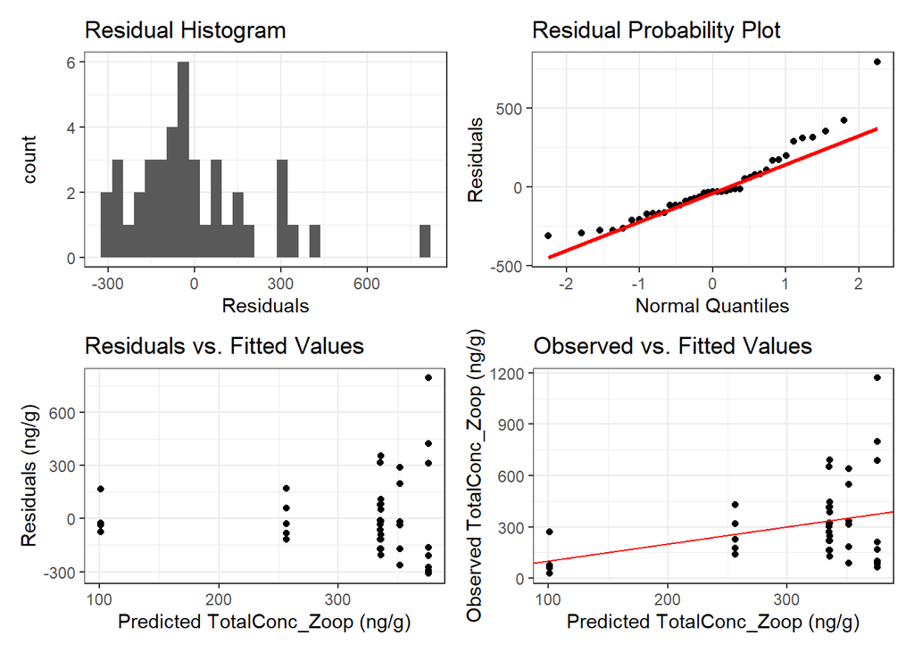

```r
df_zoop %>% plot_model_diag(TotalConc_Zoop, "ng/g", m_zoop_sta_yr)
```

```r
shapiro.test(m_zoop_sta_yr$residuals)
```

```
##
##  Shapiro-Wilk normality test
##
## data:  m_zoop_sta_yr$residuals
## W = 0.90768, p-value = 0.002817
```

The residuals deviate from a normal distribution according to the Shapiro-Wilk normality test and visual inspection. Also, the variance among groups isn’t consistent. We’ll re-run the model using the natural log of the concentration values.

```r
m_zoop_sta_yr_log <- df_zoop_log %>% lm(TotalConc_Zoop ~ Station * Year, data = .)
```

Plot the diagnostics

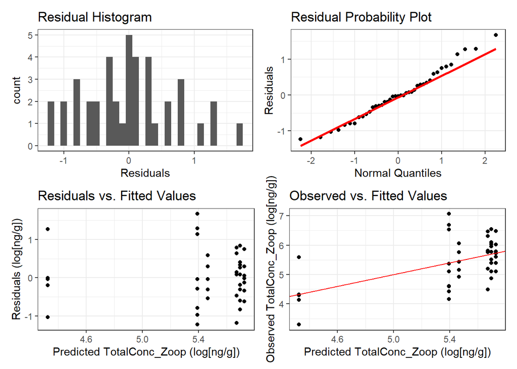

```r
df_zoop_log %>% plot_model_diag(TotalConc_Zoop, "ng/g", m_zoop_sta_yr_log, log_trans = TRUE)
```

```r
shapiro.test(m_zoop_sta_yr_log$residuals)
```

```
##
##  Shapiro-Wilk normality test
##
## data:  m_zoop_sta_yr_log$residuals
## W = 0.97934, p-value = 0.6506
```

This is much better than the model with original values. Let’s take a look at the Anova table using type 3 sum of squares for the model using natural log transformation.

```r
Anova(m_zoop_sta_yr_log, type = 3, contrasts = list(topic = contr.sum, sys = contr.sum))
```

```
## Anova Table (Type III tests)
##
## Response: TotalConc_Zoop
##               Sum Sq Df  F value  Pr(>F)
## (Intercept)  149.373  1 272.8261 < 2e-16 ***
## Station        3.248  1   5.9332 0.02009 *
## Year           0.230  2   0.2101 0.81154
## Station:Year   1.887  2   1.7230 0.19334
## Residuals     19.163 35
## ---
## Signif. codes:  0 '***' 0.001 '**' 0.01 '*' 0.05 '.' 0.1 ' ' 1
```

Well, the interaction term is not significant which means we can take a look at the main effects. Before we do this, we’ll remove the interaction from the model since it’s not necessary. We’ll stick with the model using natural log transformation.

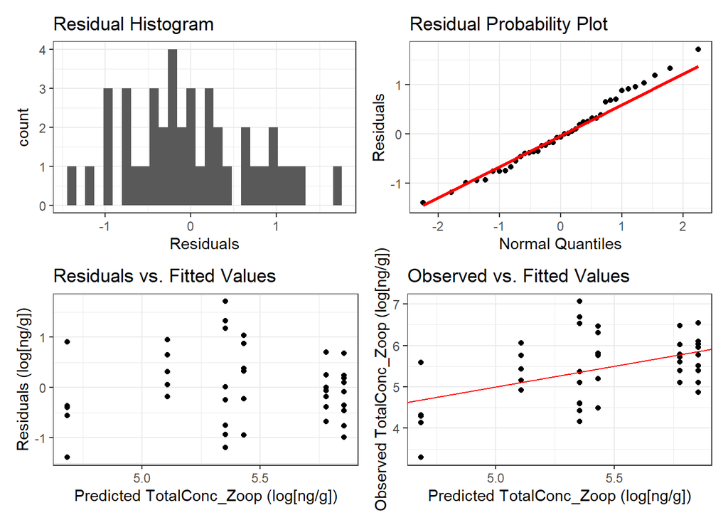

```r
m_zoop_sta_yr_log2 <- df_zoop_log %>% lm(TotalConc_Zoop ~ Station + Year, data = .)
df_zoop_log %>% plot_model_diag(TotalConc_Zoop, "ng/g", m_zoop_sta_yr_log2, log_trans = TRUE)
```

```r
shapiro.test(m_zoop_sta_yr_log2$residuals)
```

```
##
##  Shapiro-Wilk normality test
##
## data:  m_zoop_sta_yr_log2$residuals
## W = 0.98495, p-value = 0.8542
```

The diagnostics still look good with this model. Let’s take a look at the Anova table using type 2 sum of squares because of the unbalanced design.

```r
Anova(m_zoop_sta_yr_log2, type = 2)
```

```
## Anova Table (Type II tests)
##
## Response: TotalConc_Zoop
##            Sum Sq Df F value  Pr(>F)
## Station    1.8028  1  3.1690 0.08326 .
## Year       3.8276  2  3.3641 0.04546 *
## Residuals 21.0492 37
## ---
## Signif. codes:  0 '***' 0.001 '**' 0.01 '*' 0.05 '.' 0.1 ' ' 1
```

The main effect of station is not significant (p = 0.083) meaning that total pesticide concentrations in zooplankton don’t differ between SHR and STTD. However, the main effect of Year is significant, so we can take a look at the pairwise contrasts to see how concentrations differ among the years. We’ll also take a look at the pairwise contrasts for station since it is close to significant.

```r
# Contrasts for Year main effect
emmeans(m_zoop_sta_yr_log2, specs = pairwise ~ Year)
```

```
## $emmeans
##  Year emmean    SE df lower.CL upper.CL
##  2017   4.90 0.239 37     4.41     5.38
##  2018   5.57 0.189 37     5.18     5.95
##  2019   5.64 0.196 37     5.25     6.04
##
## Results are averaged over the levels of: Station
## Confidence level used: 0.95
##
## $contrasts
##  contrast            estimate    SE df t.ratio p.value
##  Year2017 - Year2018  -0.6700 0.304 37  -2.201  0.0842
##  Year2017 - Year2019  -0.7474 0.309 37  -2.420  0.0525
##  Year2018 - Year2019  -0.0774 0.274 37  -0.283  0.9570
##
## Results are averaged over the levels of: Station
## P value adjustment: tukey method for comparing a family of 3 estimates
```

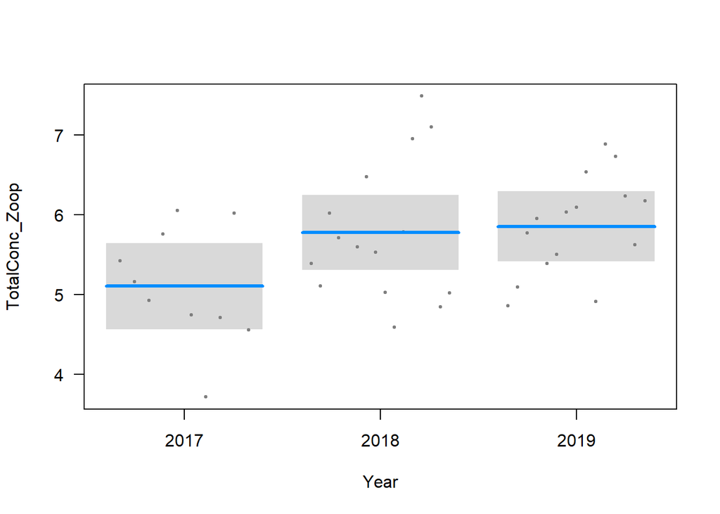

```r
visreg(m_zoop_sta_yr_log2, xvar = "Year")
```

```r
# Contrasts for Station main effect
emmeans(m_zoop_sta_yr_log2, specs = pairwise ~ Station)
```

```
## $emmeans
##  Station emmean    SE df lower.CL upper.CL
##  SHR       5.58 0.167 37     5.24     5.92
##  STTD      5.16 0.171 37     4.81     5.50
##
## Results are averaged over the levels of: Year
## Confidence level used: 0.95
##
## $contrasts
##  contrast   estimate    SE df t.ratio p.value
##  SHR - STTD    0.424 0.238 37   1.780  0.0833
##
## Results are averaged over the levels of: Year
```

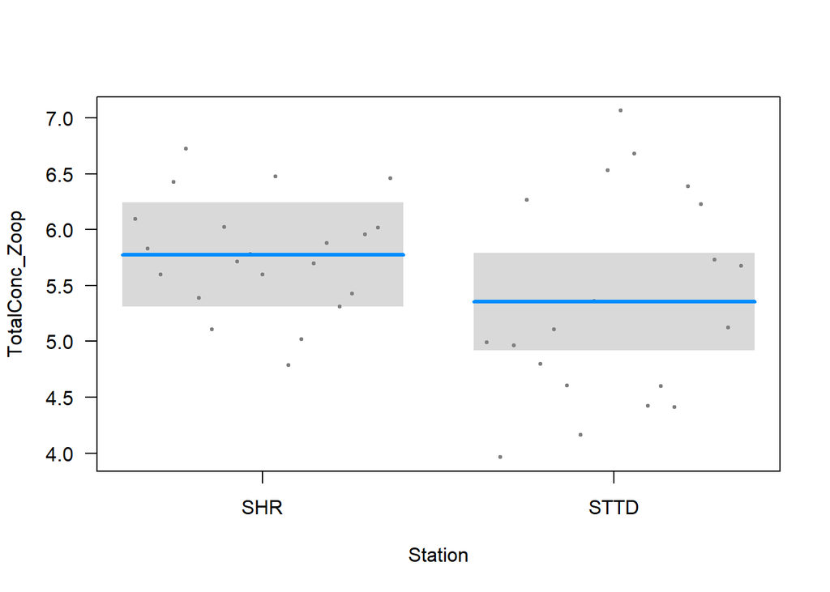

```r
visreg(m_zoop_sta_yr_log2, xvar = "Station")
```

Pairwise tests indicate that total pesticide concentration in zooplankton in 2019 is marginally significantly higher than 2017, but the p-value is 0.053. Also, the p-value isn’t significant, but SHR is slightly higher than STTD.

# Water Analysis

```r
# Prepare water concentration data for analysis
df_water <- df_conc_flow_all_c %>%
  select(-TotalConc_Zoop) %>%
  # only include 2019 since that was the only year water samples were collected
    # at STTD
  filter(year(Date) == 2019) %>%
  drop_na()
```

## Exploratory Plots

Before running the analyses, lets take a look at how the total pesticide concentrations in water vary with daily average net flow for each station.

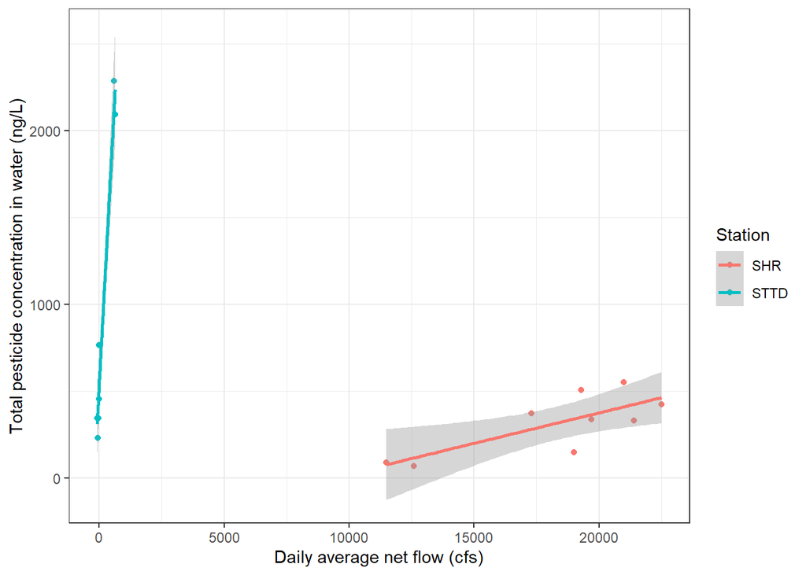

```r
df_water %>%
  ggplot(aes(x = DailyAvgNetFlow, y = TotalConc_Water, color = Station)) +
  geom_point() +
  geom_smooth(method = "lm", formula = y ~ x) +
  labs(
    x = "Daily average net flow (cfs)",
    y = "Total pesticide concentration in water (ng/L)"
  ) +
  theme_bw()
```

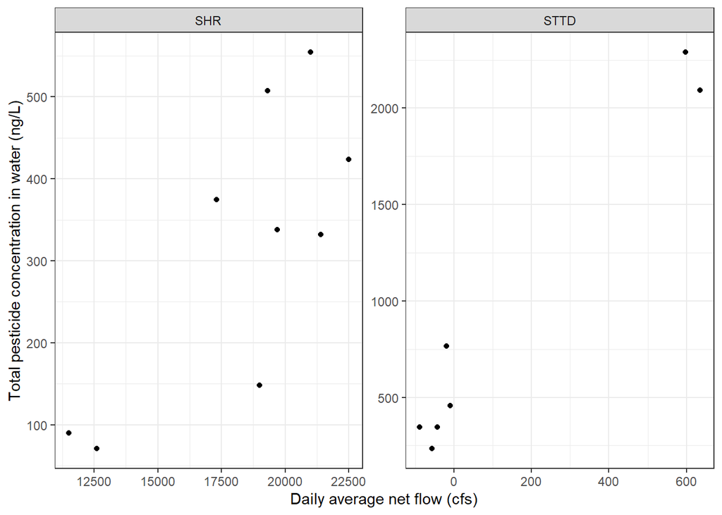

```r
df_water %>%
  ggplot(aes(x = DailyAvgNetFlow, y = TotalConc_Water)) +
  geom_point() +
  facet_wrap(vars(Station), scales = "free") +
  labs(
    x = "Daily average net flow (cfs)",
    y = "Total pesticide concentration in water (ng/L)"
  ) +
  theme_bw()
```

Next, lets look at a boxplot comparing total pesticide concentrations in water between stations.

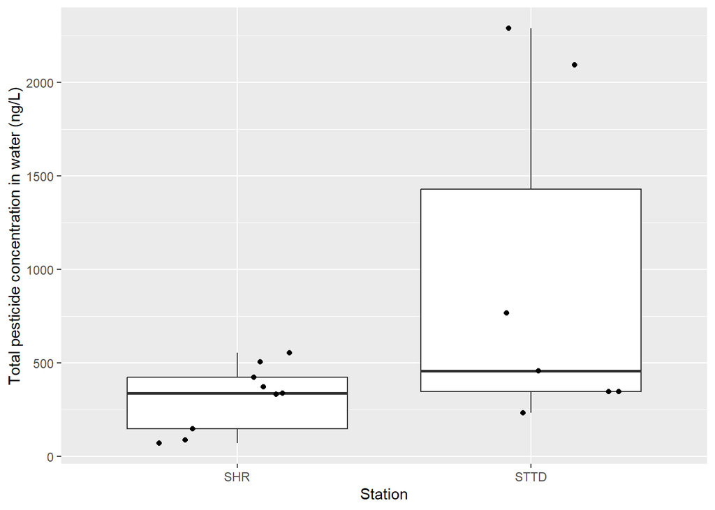

```r
df_water %>%
  ggplot(aes(x = Station, y = TotalConc_Water)) +
  geom_boxplot(outlier.shape = NA) +
  geom_jitter(width = 0.3) +
  ylab("Total pesticide concentration in water (ng/L)")
```

STTD seems to have higher concentrations with much more variation than SHR.

Now, let’s see how total concentrations varied seasonally in 2019 for each station.

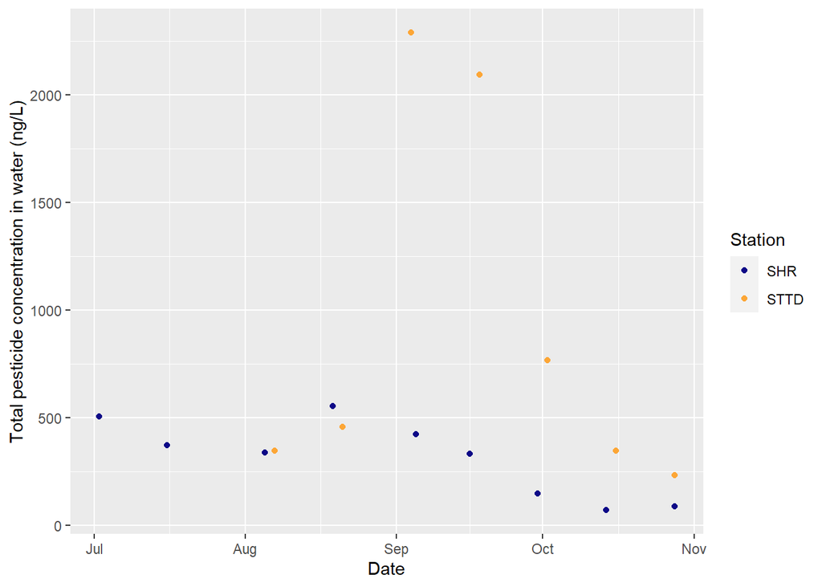

```r
df_water %>%
  ggplot(aes(x = Date, y = TotalConc_Water, color = Station)) +
  geom_point() +
  scale_color_viridis_d(option = "plasma", end = 0.8) +
  labs(x = "Date", y = "Total pesticide concentration in water (ng/L)")
```

Lastly, let’s take a look at the histogram of all total pesticide concentrations in water to look at its distribution.

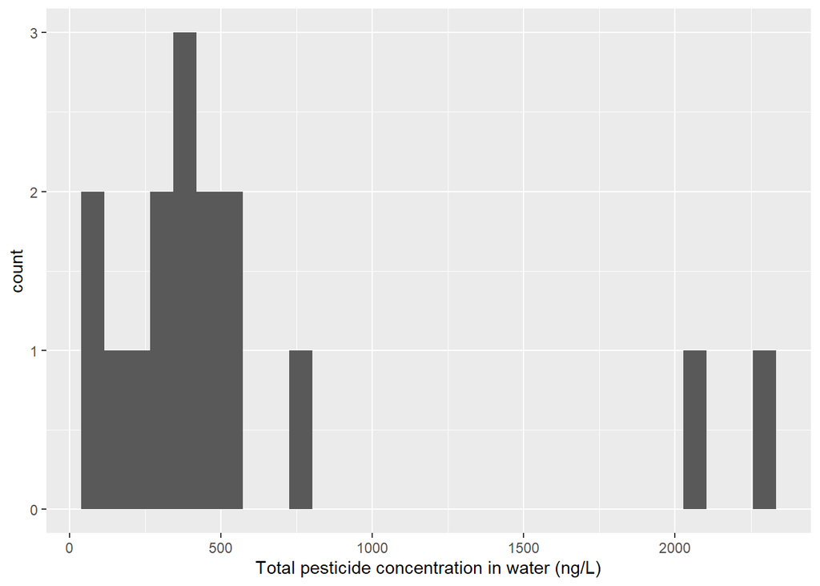

```r
df_water %>%
  ggplot(aes(x = TotalConc_Water)) +
  geom_histogram() +
  xlab("Total pesticide concentration in water (ng/L)")
```

We may need to transform the water concentration data for the analyses.

## Analyses

### Model with Station and Flow

We’ll create a linear model of the water concentrations as a function of the interaction between station and daily average net flow. We’ll start with the original concentration values, but we may need to transform them. This model will allow us to examine:

1. Do total pesticide concentrations in water significantly respond to flow at either or both SHR and STTD?
2. Whether total pesticide concentrations in water are significantly higher at one of the stations controlling for the effect of flow. This can only be assessed if the interaction between station and daily average net flow isn’t significant.

```r
m_water_sta_flow <- df_water %>% lm(TotalConc_Water ~ Station * DailyAvgNetFlow, data = .)
```

Plot the diagnostics

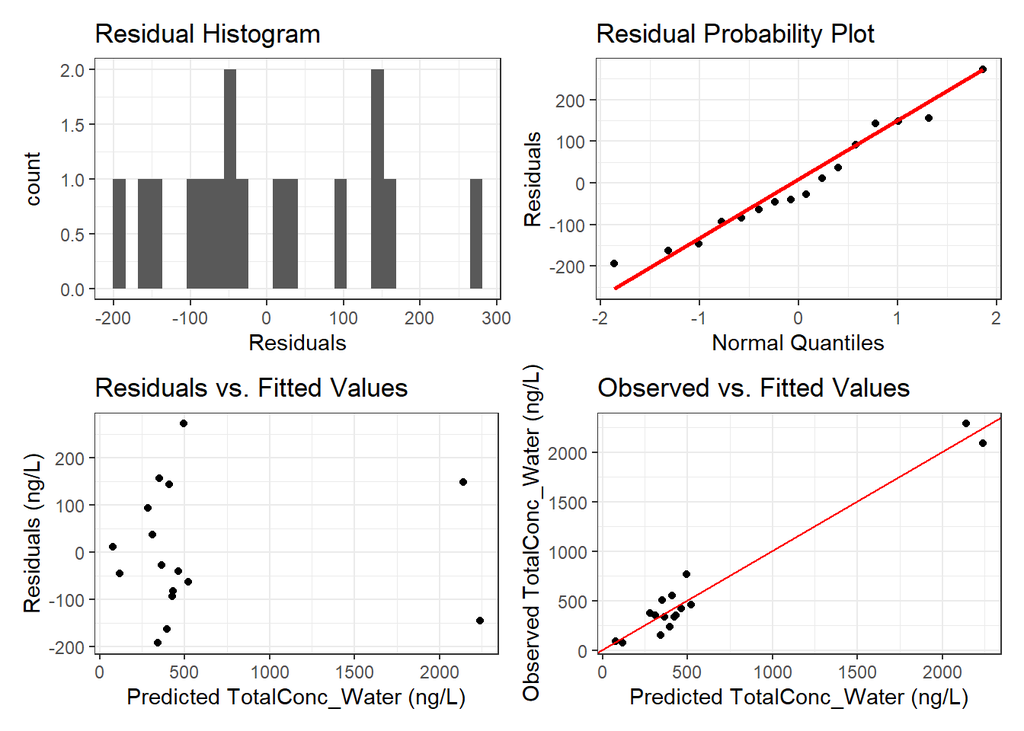

```r
df_water %>% plot_model_diag(TotalConc_Water, "ng/L", m_water_sta_flow)
```

```r
shapiro.test(m_water_sta_flow$residuals)
```

```
##
##  Shapiro-Wilk normality test
##
## data:  m_water_sta_flow$residuals
## W = 0.95824, p-value = 0.63
```

The residuals look pretty good according to the Shapiro-Wilk normality test and visual inspection; however, there are two values with much higher total pesticide concentrations which could be exerting a lot of leverage on the model. Let’s take a look at the Anova table using type 3 sum of squares.

```r
Anova(m_water_sta_flow, type = 3, contrasts = list(topic = contr.sum, sys = contr.sum))
```

```
## Anova Table (Type III tests)
##
## Response: TotalConc_Water
##                          Sum Sq Df  F value    Pr(>F)
## (Intercept)               35714  1   1.6471  0.223591
## Station                  243299  1  11.2204  0.005783 **
## DailyAvgNetFlow          144444  1   6.6615  0.024054 *
## Station:DailyAvgNetFlow 4321039  1 199.2777 7.765e-09 ***
## Residuals                260202 12
## ---
## Signif. codes:  0 '***' 0.001 '**' 0.01 '*' 0.05 '.' 0.1 ' ' 1
```

The interaction between station and daily average net flow is significant indicating that the regression slopes are different between the two stations. This is corroborated by the concentration vs flow plots above. To look at how flow affects total pesticide concentrations in water, it would be best to run separate models for each station.

#### SHR

We’ll start with SHR

```r
df_water_shr <- df_water %>% filter(Station == "SHR")

m_water_flow_shr <- df_water_shr %>% lm(TotalConc_Water ~ DailyAvgNetFlow, data = .)
```

Plot the diagnostics

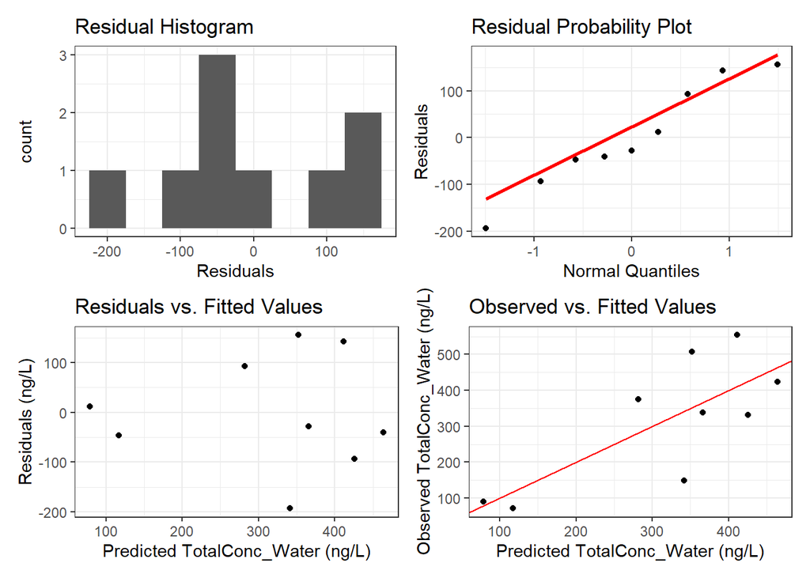

```r
df_water_shr %>% plot_model_diag(TotalConc_Water, "ng/L", m_water_flow_shr, bins = 8)
```

```r
shapiro.test(m_water_flow_shr$residuals)
```

```
##
##  Shapiro-Wilk normality test
##
## data:  m_water_flow_shr$residuals
## W = 0.95137, p-value = 0.7051
```

The diagnostics look pretty good with this model, so we’ll take a closer look at it.

```r
summary(m_water_flow_shr)
```

```
##
## Call:
## lm(formula = TotalConc_Water ~ DailyAvgNetFlow, data = .)
##
## Residuals:
##     Min      1Q  Median      3Q     Max
## -193.38  -46.45  -28.03   92.38  155.64
##
## Coefficients:
##                   Estimate Std. Error t value Pr(>|t|)
## (Intercept)     -324.17506  209.05497  -1.551   0.1649
## DailyAvgNetFlow    0.03503    0.01123   3.119   0.0169 *
## ---
## Signif. codes:  0 '***' 0.001 '**' 0.01 '*' 0.05 '.' 0.1 ' ' 1
##
## Residual standard error: 121.9 on 7 degrees of freedom
## Multiple R-squared:  0.5815, Adjusted R-squared:  0.5217
## F-statistic: 9.725 on 1 and 7 DF,  p-value: 0.01688
```

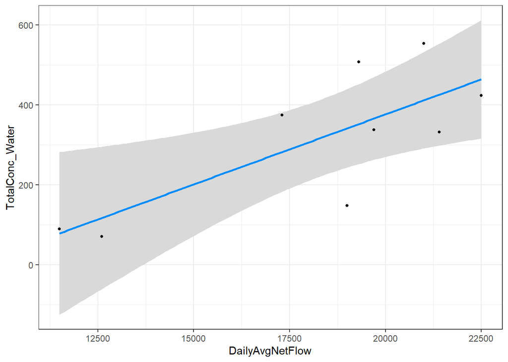

```r
visreg(m_water_flow_shr, gg = TRUE) + theme_bw() + geom_point(size = 1)
```

Total pesticide concentrations increase significantly with flow at the SHR station; however, there is a gap in samples between 13,000-17,000 cfs.

#### STTD

Next, we’ll look at STTD

```r
df_water_sttd <- df_water %>% filter(Station == "STTD")

m_water_flow_sttd <- df_water_sttd %>% lm(TotalConc_Water ~ DailyAvgNetFlow, data = .)
```

Plot the diagnostics

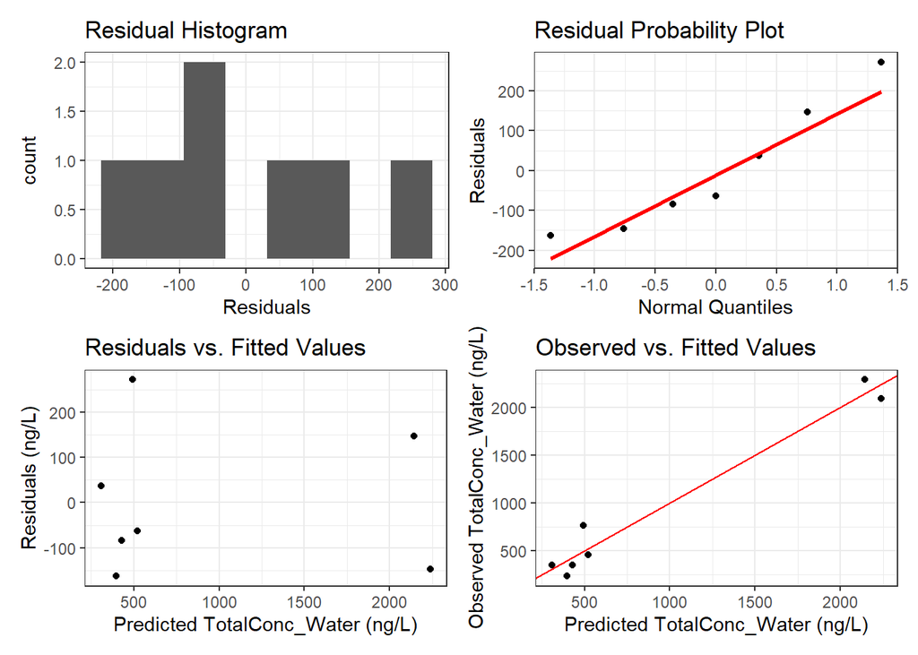

```r
df_water_sttd %>% plot_model_diag(TotalConc_Water, "ng/L", m_water_flow_sttd, bins = 8)
```

```r
shapiro.test(m_water_flow_sttd$residuals)
```

```
##
##  Shapiro-Wilk normality test
##
## data:  m_water_flow_sttd$residuals
## W = 0.91096, p-value = 0.4025
```

The diagnostics look pretty good with this model, so let’s take a closer look at this one.

```r
summary(m_water_flow_sttd)
```

```
##
## Call:
## lm(formula = TotalConc_Water ~ DailyAvgNetFlow, data = .)
##
## Residuals:
##       1       2       3       4       5       6       7
##  -83.68  -63.28  147.50 -146.58  272.14   36.88 -162.98
##
## Coefficients:
##                 Estimate Std. Error t value Pr(>|t|)
## (Intercept)     546.9311    74.2362   7.367 0.000724 ***
## DailyAvgNetFlow   2.6669     0.2232  11.948 7.24e-05 ***
## ---
## Signif. codes:  0 '***' 0.001 '**' 0.01 '*' 0.05 '.' 0.1 ' ' 1
##
## Residual standard error: 176.8 on 5 degrees of freedom
## Multiple R-squared:  0.9662, Adjusted R-squared:  0.9594
## F-statistic: 142.7 on 1 and 5 DF,  p-value: 7.241e-05
```

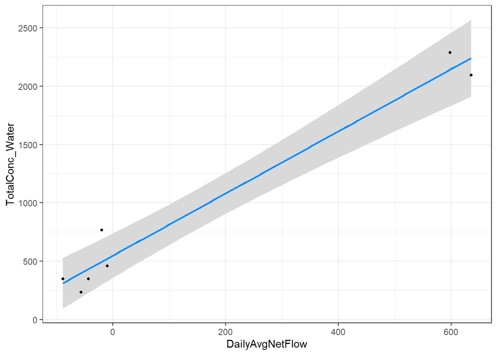

```r
visreg(m_water_flow_sttd, gg = TRUE) + theme_bw() + geom_point(size = 1)
```

Total pesticide concentrations increase significantly with flow at the STTD station, but there are two values with flows of about 600 cfs that have a lot leverage on the model.

### Station comparison

Next, let’s compare total pesticide concentrations in water between the two stations, SHR and STTD. Since samples were only collected at both stations in 2019, we can run a simple t-test to compare them. The histogram of all water concentrations above showed that they are not normally-distributed. Let’s take a look at the natural log transformed values to see if we can use these for the t-test.

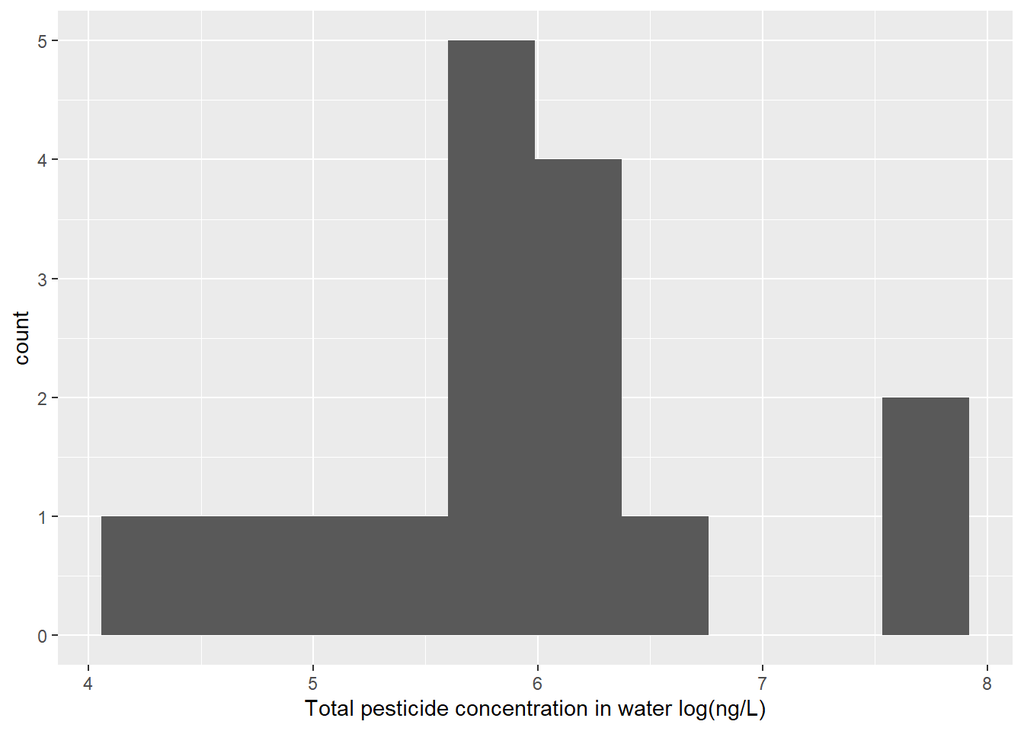

```r
df_water_log <- df_water %>% mutate(TotalConc_Water = log(TotalConc_Water))

df_water_log %>%
  ggplot(aes(x = TotalConc_Water)) +
  geom_histogram(bins = 10) +
  xlab("Total pesticide concentration in water log(ng/L)")
```

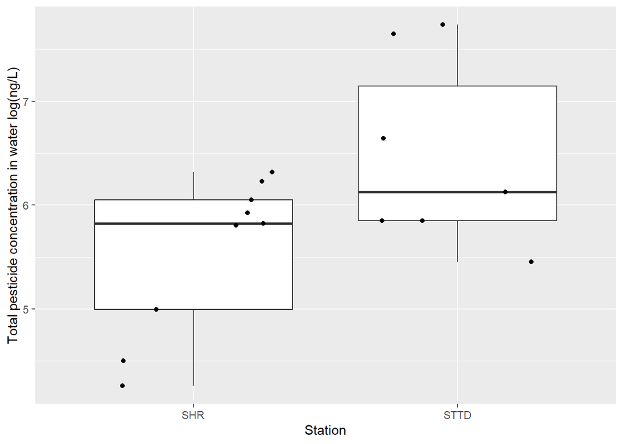

```r
df_water_log %>%
  ggplot(aes(x = Station, y = TotalConc_Water)) +
  geom_boxplot(outlier.shape = NA) +
  geom_jitter(width = 0.3) +
  ylab("Total pesticide concentration in water log(ng/L)")
```

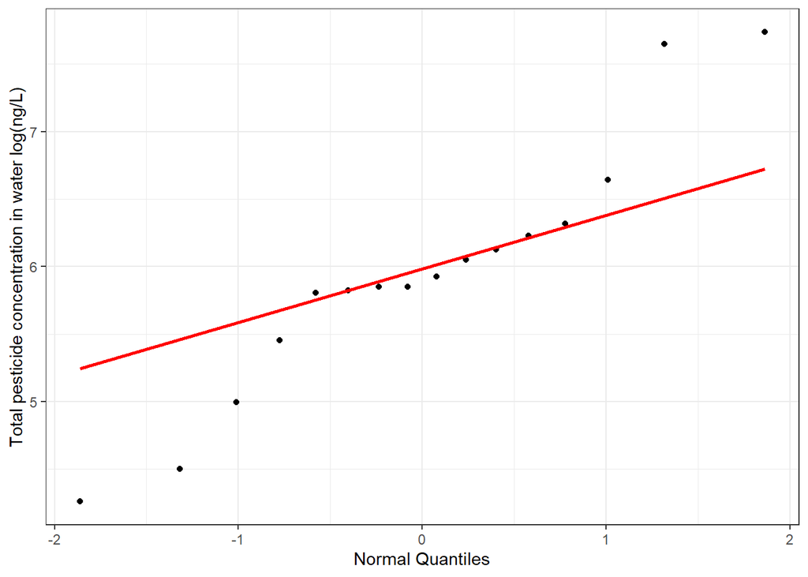

```r
df_water_log %>%
  ggplot(aes(sample = TotalConc_Water)) +
  labs(
    x = "Normal Quantiles",
    y = "Total pesticide concentration in water log(ng/L)"
  ) +
  stat_qq() +
  stat_qq_line(linewidth = 1, color = 'red') +
  theme_bw()
```

```r
shapiro.test(df_water_log$TotalConc_Water)
```

```
##
##  Shapiro-Wilk normality test
##
## data:  df_water_log$TotalConc_Water
## W = 0.93391, p-value = 0.2809
```

The natural log transformed values seem to be more normally distributed and have relatively equal variances between SHR and STTD. Let’s run Welch’s two-sample t-test to compare the means of total pesticide concentration in water between SHR and STTD.

```r
df_water_log %>% t.test(TotalConc_Water ~ Station, data = .)
```

```
##
##  Welch Two Sample t-test
##
## data:  TotalConc_Water by Station
## t = -2.1709, df = 11.742, p-value = 0.05119
## alternative hypothesis: true difference in means between group SHR and group STTD is not equal to 0
## 95 percent confidence interval:
##  -1.858996839  0.005652187
## sample estimates:
##  mean in group SHR mean in group STTD
##           5.545113           6.471786
```

The mean total pesticide concentration in water was marginally significantly higher at STTD than SHR during 2019.

# Overall Conclusions

Models including station and daily average net flow for both response variables, water and zooplankton concentration, had the unusual situation where the ranges of the flows didn’t overlap between the two stations; therefore, it may not make sense to interpret these Station-Flow models. Other conclusions are grouped by the response variable.

Total pesticide concentrations in Zooplankton: